# Community Contribution QQPlot and Quantiles

# 1. Introduction

We start by loading some random data. I’ve found a package [tidytuesdayR](https://cran.r-project.org/web/packages/tidytuesdayR/index.html), which contains a lot of fun example data, perfect for illustrating certain concepts and playing around with.

Here, we import a dataset that looks at the age difference between two (romantic) leads in a movie. I thought this was a fun dataset, but the choice here is irrelevant.

```r
library(tidyverse)
library(tidytuesdayR)
library(tidyr)

tuesdata <- tidytuesdayR::tt_load('2023-02-14')
age_gaps <- tuesdata$age_gaps
```

While playing around with QQPlots, and especially when reproducing them, I realized that there were a few subtleties involved with it:

1. My naive QQPlot construction did not match with the ones generated using ggplot or qqnorm.
2. My straight line does not coincide with the one in ggplot/qqnorm (for reference my naive choice of straight line was running a regression).

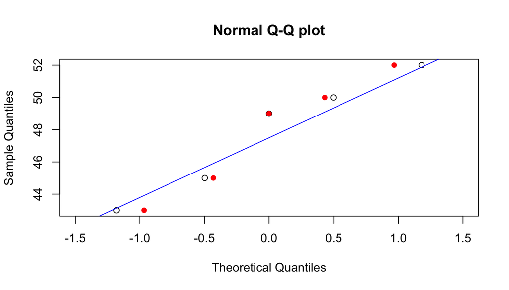

```r
y = head(age_gaps$age_difference, 5)

# 1. Sort the data
sorted_data <- sort(y)

# 2. Compute the theoretical quantiles
n <- length(sorted_data)
#probabilities <- (1:n - 0.5) / n
probabilities <- (1:n) / (n+1)
theoretical_quantiles <- qnorm(probabilities)

qqnorm(y,
       axes = TRUE,
       xlim = c(-1.5,1.5),
       frame.plot = TRUE,
       main = "Normal Q-Q plot",
       xlab = "Theoretical Quantiles",
       ylab = "Sample Quantiles")
qqline(y, col = "blue")
points(theoretical_quantiles, sorted_data, col = "red", pch = 16)
```

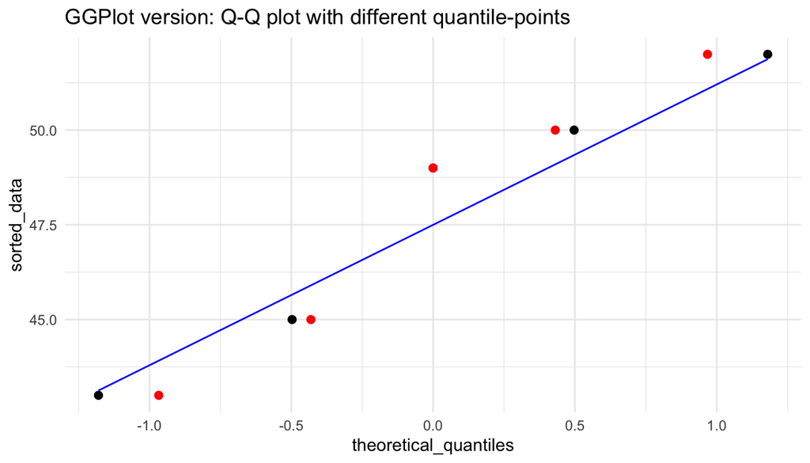

```r
probabilities <- (1:n) / (n+1)
theoretical_quantiles <- qnorm(probabilities)
naive <- data.frame(theoretical_quantiles,sorted_data)
ggplot() +
  geom_qq(data = head(age_gaps, 5), aes(sample = age_difference), size = 2) +
  geom_qq_line(data = head(age_gaps, 5), aes(sample = age_difference),color = "blue",line.p = c(.25, .75)) +
  geom_point(data = naive, aes(x = theoretical_quantiles, y = sorted_data), color = "red", size = 2) +
  ggtitle("GGPlot version: Q-Q plot with different quantile-points") +
  theme_minimal()
```

What about the different choices of lines?

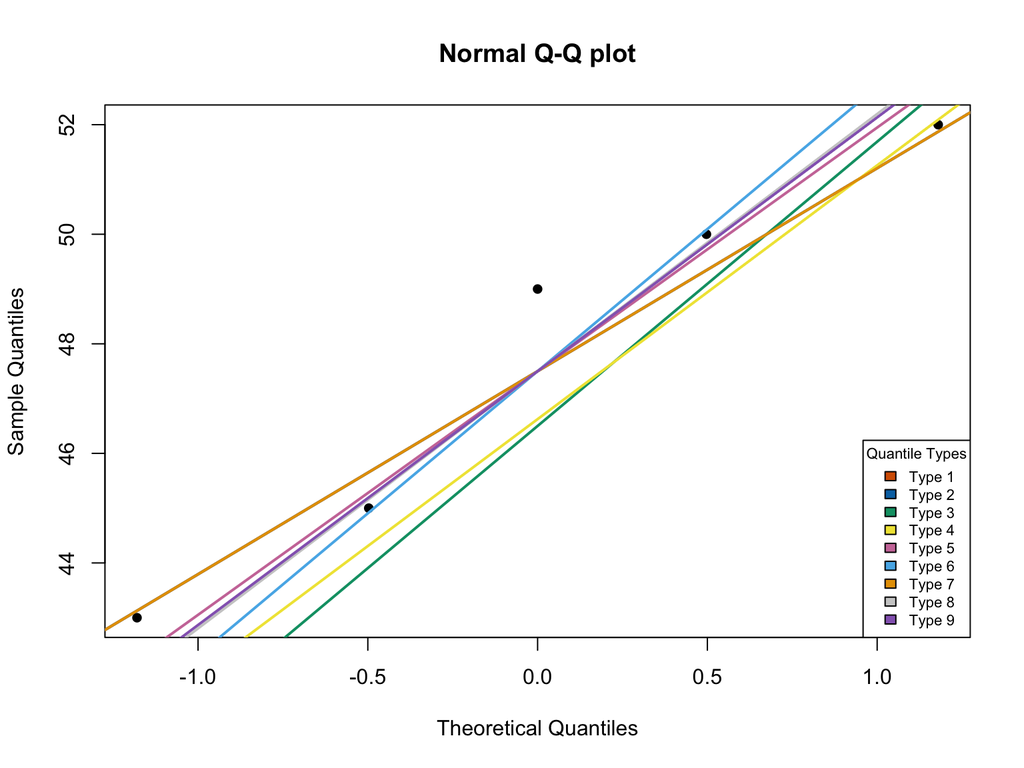

```r
y = head(age_gaps$age_difference, 5)

# Aesthetic color choices
colors <- c("#D55E00", "#0072B2", "#009E73", "#F0E442", "#CC79A7", "#56B4E9", "#E69F00", "grey80", "#9467bd")

# Start the Q-Q plot
qqnorm(y, main = "Normal Q-Q plot", xlab = "Theoretical Quantiles", ylab = "Sample Quantiles", col = "black", pch = 16)

# Add the various qq lines for the different types
for (i in 1:9) {
  qqline(y, col = colors[i], lwd = 2, qtype = i)
}

# Add legend
legend("bottomright", legend = paste("Type", 1:9), fill = colors, cex = 0.7, title = "Quantile Types")
```

**Answer: Quantile function is more intricate:** Quantiles are random variables, and therefore we need to define an estimator for them. There are various ways of estimating the quantile function. In particular there are 9 specific types that are standard and have been proposed in [**Hyndman-Fan**](https://www.amherst.edu/media/view/129116/original/Sample+Quantiles.pdf).

# 2. Choice of Quantile function

We now examine the nine types of quantile functions proposed in [**Hyndman-Fan**](https://www.amherst.edu/media/view/129116/original/Sample+Quantiles.pdf):

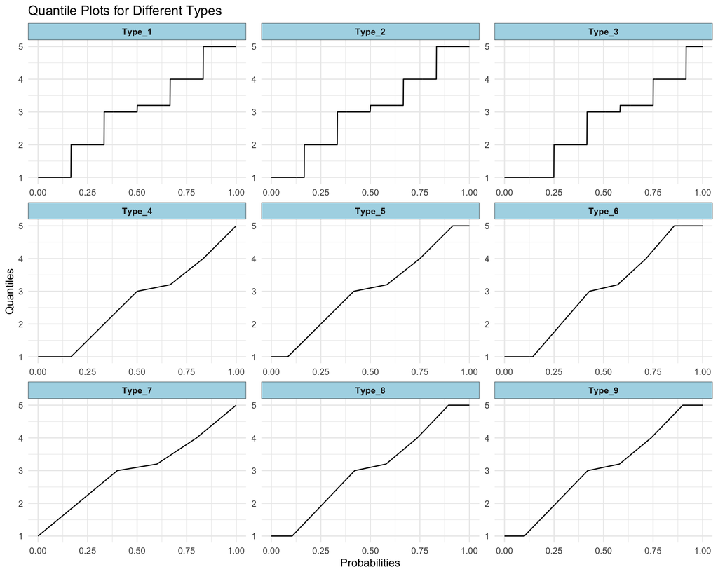

```r
library(dplyr)

# Generate the data
data <- c(1,2,3,3.2,4,5)
probs <- seq(0, 1, 0.001)

# Create a data frame for all types
df <- data.frame()

for (i in 1:9) {
  quantiles <- quantile(data, probs=probs, type=i)
  df_temp <- data.frame(probs, quantiles, type = factor(paste0("Type_", 1:9)[i]))
  df <- rbind(df, df_temp)
}

# Create the ggplot
p <- ggplot(df, aes(x=probs, y=quantiles)) +
  geom_line() +
  labs(x="Probabilities",
       y="Quantiles",
       title="Quantile Plots for Different Types") +
  theme_minimal() +
  facet_wrap(~type, scales = "free", ncol = 3) +
  theme(strip.background = element_rect(fill = "lightblue", colour = "black", linewidth = .25),
        strip.text = element_text(face = "bold"))

# Display the plot
print(p)
```

# 3. What are these different sample quantiles?

Traditionally there are 9 quantile estimator types defined in [**Hyndman-Fan**](https://www.amherst.edu/media/view/129116/original/Sample+Quantiles.pdf).

## 3.1. The first three types are locally constant functions.

For example type 1 is the empirical distribution function, where $m=0$ and

This precisely corresponds to the case, where we jump to the next quantile once we hit a certain data point (in particular this type of quantile function is usually used when generating bootstrap analyses). Namely, the probabilities (inverse of the quantile function) are

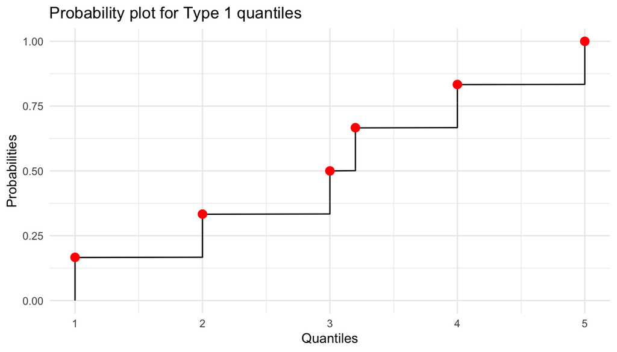

```r
filtered_df <- subset(df, type == 'Type_1')
pts <- data.frame(x = (1:length(data)) / (n+1),y = data)
ggplot(filtered_df, aes(x=quantiles, y=probs)) +
  geom_line() +
  geom_point(data=pts,
             aes(x=y, y=x),
             color="red",
             size=3) +
  labs(y="Probabilities",
       x="Quantiles",
       title="Probability plot for Type 1 quantiles") +
  theme_minimal()
```

The other two cases are similar except that the jumps are defined slightly differently. In the type 2 case, the probability along the jump is averaged (i.e. in the middle), and therefore its graph is indistinguishable compared to the above one. The third type can be visualized nicely:

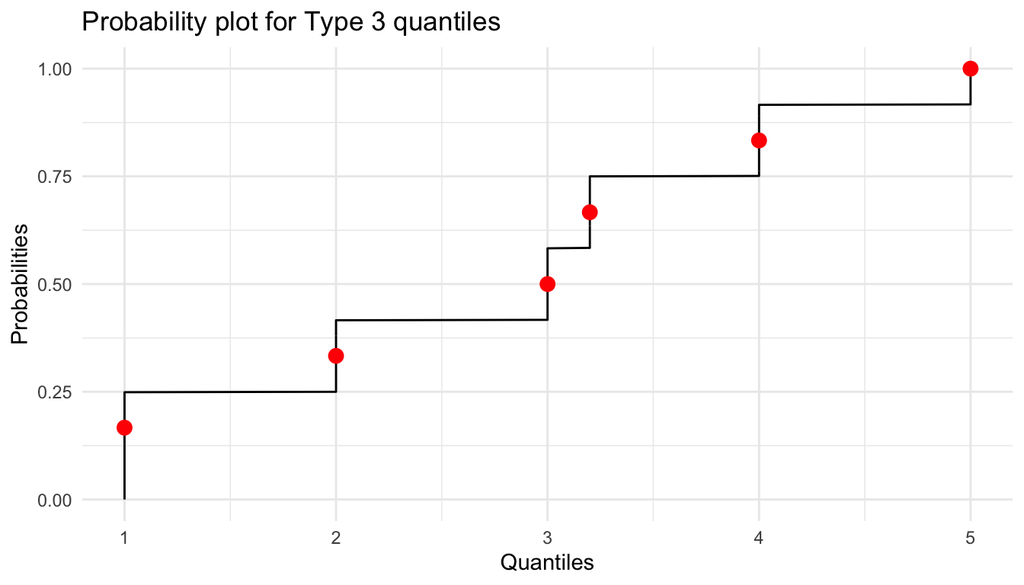

```r
filtered_df <- subset(df, type == 'Type_3')
pts <- data.frame(x = (1:length(data)) / (n+1),y = data)
ggplot(filtered_df, aes(x=quantiles, y=probs)) +
  geom_line() +
  geom_point(data=pts,
             aes(x=y, y=x),
             color="red",
             size=3) +
  labs(y="Probabilities",
       x="Quantiles",
       title="Probability plot for Type 3 quantiles") +
  theme_minimal()
```

## 3.2. The remaining six types are piecewise continuous functions

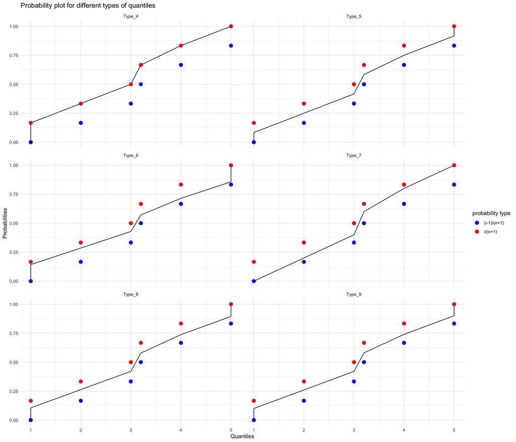

```r
filtered_df <- subset(df, type %in% paste0('Type_', 4:9))

pts <- data.frame(x = (1:length(data)) / (n+1),y = data)
pts1 <- data.frame(x = (1:length(data) - 1) / (n+1),y = data)

# Plot with faceting
ggplot(filtered_df, aes(x=quantiles, y=probs)) +
  geom_line() +
  geom_point(data=pts, aes(x=y, y=x, color="i/(n+1)"), size=3) +
  geom_point(data=pts1, aes(x=y, y=x, color="(i-1)/(n+1)"), size=3) +
  labs(y="Probabilities",
       x="Quantiles",
       title="Probability plot for different types of quantiles") +
  scale_color_manual(name = "probability type",
                     values = c("i/(n+1)" = "red", "(i-1)/(n+1)" = "blue")) +
  theme_minimal() +
  facet_wrap(~type, ncol=2)
```